# Correction des exercices

Author

Benoît Simon-Bouhet

Published

October 1, 2022

# Chapitre 1

## Exercice 1.5

*Dans votre dossier de travail, créez un nouveau script que vous nommerez `ExoDiamonds.R`. Vous prendrez soin d’ajouter autant de commentaires que nécessaire dans votre script afin de le structurer correctement.*

1. *Téléchargez (si besoin) et chargez le package `ggplot2`*

```r
# Pour installer ggplot2 dé-commenter la ligne ci-dessous, si nécéssaire seulement
# install.packages("ggplot2")

# chargement du package
library(ggplot2)
```

2. *Chargez le jeu de données `diamonds` grâce à la commande `data(diamonds)`*

```r
# chargement des données
data(diamonds)
```

3. *Déterminez le nombre de lignes et de colonnes de ce tableau nommé `diamonds`*

```r
# Nombre de lignes et de colonnes du tableau diamonds
str(diamonds)
```

```
tibble [53,940 × 10] (S3: tbl_df/tbl/data.frame)
 $ carat  : num [1:53940] 0.23 0.21 0.23 0.29 0.31 0.24 0.24 0.26 0.22 0.23 ...
 $ cut    : Ord.factor w/ 5 levels "Fair"<"Good"<..: 5 4 2 4 2 3 3 3 1 3 ...
 $ color  : Ord.factor w/ 7 levels "D"<"E"<"F"<"G"<..: 2 2 2 6 7 7 6 5 2 5 ...
 $ clarity: Ord.factor w/ 8 levels "I1"<"SI2"<"SI1"<..: 2 3 5 4 2 6 7 3 4 5 ...
 $ depth  : num [1:53940] 61.5 59.8 56.9 62.4 63.3 62.8 62.3 61.9 65.1 59.4 ...
 $ table  : num [1:53940] 55 61 65 58 58 57 57 55 61 61 ...
 $ price  : int [1:53940] 326 326 327 334 335 336 336 337 337 338 ...
 $ x      : num [1:53940] 3.95 3.89 4.05 4.2 4.34 3.94 3.95 4.07 3.87 4 ...
 $ y      : num [1:53940] 3.98 3.84 4.07 4.23 4.35 3.96 3.98 4.11 3.78 4.05 ...
 $ z      : num [1:53940] 2.43 2.31 2.31 2.63 2.75 2.48 2.47 2.53 2.49 2.39 ...
```

```r
# ou
dim(diamonds)
```

```
[1] 53940    10
```

```r
# ou
nrow(diamonds)  # Nombre de lignes
```

```
[1] 53940
```

```r
ncol(diamonds)  # Nombre de colonnes
```

```
[1] 10
```

```r
# Ou, puisque c'est un tibble, on l'affiche simplement dans la console
diamonds
```

```
# A tibble: 53,940 × 10
   carat cut       color clarity depth table price     x     y     z
   <dbl> <ord>     <ord> <ord>   <dbl> <dbl> <int> <dbl> <dbl> <dbl>
 1  0.23 Ideal     E     SI2      61.5    55   326  3.95  3.98  2.43
 2  0.21 Premium   E     SI1      59.8    61   326  3.89  3.84  2.31
 3  0.23 Good      E     VS1      56.9    65   327  4.05  4.07  2.31
 4  0.29 Premium   I     VS2      62.4    58   334  4.2   4.23  2.63
 5  0.31 Good      J     SI2      63.3    58   335  4.34  4.35  2.75
 6  0.24 Very Good J     VVS2     62.8    57   336  3.94  3.96  2.48
 7  0.24 Very Good I     VVS1     62.3    57   336  3.95  3.98  2.47
 8  0.26 Very Good H     SI1      61.9    55   337  4.07  4.11  2.53
 9  0.22 Fair      E     VS2      65.1    61   337  3.87  3.78  2.49
10  0.23 Very Good H     VS1      59.4    61   338  4     4.05  2.39
# … with 53,930 more rows
```

4. *Créez un nouveau tableau que vous nommerez `diamants_chers` qui contiendra uniquement les informations des diamants dont le prix est supérieur ou égal à $15000.*

```r
# Nouveau tableau contenant uniquement les diamants de plus de 15000$
diamants_chers <- subset(diamonds, price > 15000)
```

5. *Combien de diamants coûtent $15000 ou plus ?*

```r
# Combien de diamants valent plus de 15000$ ?
# C'est la même question qu'à la question 3 ci-dessus, mais avec le tableau diamants_chers
nrow(diamants_chers)
```

```
[1] 1655
```

```r
diamants_chers
```

```
# A tibble: 1,655 × 10
   carat cut       color clarity depth table price     x     y     z
   <dbl> <ord>     <ord> <ord>   <dbl> <dbl> <int> <dbl> <dbl> <dbl>
 1  1.54 Premium   E     VS2      62.3    58 15002  7.31  7.39  4.58
 2  1.19 Ideal     F     VVS1     61.5    55 15005  6.82  6.84  4.2
 3  2.1  Premium   I     SI1      61.5    57 15007  8.25  8.21  5.06
 4  1.69 Ideal     D     SI1      60.8    57 15011  7.69  7.71  4.68
 5  1.5  Very Good G     VVS2     62.9    56 15013  7.22  7.32  4.57
 6  1.73 Very Good G     VS1      62.8    57 15014  7.57  7.72  4.8
 7  2.02 Premium   G     SI2      63      59 15014  8.05  7.95  5.03
 8  2.05 Very Good F     SI2      61.9    56 15017  8.13  8.18  5.05
 9  1.5  Very Good F     VS1      61.6    58 15022  7.35  7.43  4.55
10  1.82 Very Good G     SI1      62.7    58 15025  7.68  7.75  4.84
# … with 1,645 more rows
```

```r
# On peut aussi faire ceci, à partir du tableau de départ
sum(diamonds$price > 15000, na.rm = TRUE)
```

```
[1] 1655
```

6. *Cela représente quelle proportion du jeu de données de départ ?*

```r
# Proportion des diamants de depart qui valent plus de 15000$
nrow(diamants_chers) / nrow(diamonds)
```

```
[1] 0.03068224
```

```r
# Ou
mean(diamonds$price > 15000, na.rm = TRUE)
```

```
[1] 0.03068224
```

7. *Triez ce tableau par ordre de prix décroissants et affichez les informations des 20 diamants les plus chers.*

```r
# Identification des permutations à effectuer pour trier diamants_chers par ordre
# de prix décroissants
permut <- order(diamants_chers$price, decreasing = TRUE)

# Tableau diamants_chers ré-ordonné par ordre de prix décroissant
diam_tri <- diamants_chers[permut, ]

# Attention a ne pas oublier la virgule à la fin entre les crochets:
# On réordonne les lignes (permut est placé avant la virgule) et on
# récupère toutes les colonnes (on ne met rien après la virgule)

# Affichage des infos sur les 20 diamants les plus chers
diam_tri[1:20,]
```

```
# A tibble: 20 × 10
   carat cut       color clarity depth table price     x     y     z
   <dbl> <ord>     <ord> <ord>   <dbl> <dbl> <int> <dbl> <dbl> <dbl>
 1  2.29 Premium   I     VS2      60.8    60 18823  8.5   8.47  5.16
 2  2    Very Good G     SI1      63.5    56 18818  7.9   7.97  5.04
 3  1.51 Ideal     G     IF       61.7    55 18806  7.37  7.41  4.56
 4  2.07 Ideal     G     SI2      62.5    55 18804  8.2   8.13  5.11
 5  2    Very Good H     SI1      62.8    57 18803  7.95  8     5.01
 6  2.29 Premium   I     SI1      61.8    59 18797  8.52  8.45  5.24
 7  2.04 Premium   H     SI1      58.1    60 18795  8.37  8.28  4.84
 8  2    Premium   I     VS1      60.8    59 18795  8.13  8.02  4.91
 9  1.71 Premium   F     VS2      62.3    59 18791  7.57  7.53  4.7
10  2.15 Ideal     G     SI2      62.6    54 18791  8.29  8.35  5.21
11  2.8  Good      G     SI2      63.8    58 18788  8.9   8.85  0
12  2.05 Ideal     G     SI1      61.9    57 18787  8.1   8.16  5.03
13  2.05 Premium   F     SI2      60.2    59 18784  8.28  8.33  5
14  2.03 Very Good H     SI1      63      60 18781  8     7.93  5.02
15  1.6  Ideal     F     VS1      62      56 18780  7.47  7.52  4.65
16  2.06 Ideal     I     VS2      62.2    55 18779  8.15  8.19  5.08
17  1.51 Very Good F     VVS1     62.6    59 18777  7.33  7.24  4.56
18  1.71 Ideal     G     VVS2     62.1    55 18768  7.66  7.63  4.75
19  2.55 Premium   I     VS1      61.8    62 18766  8.7   8.65  5.36
20  2.08 Ideal     H     SI1      58.7    60 18760  8.36  8.4   4.92
```

```r
# Ou
head(diam_tri, n = 20)
```

```
# A tibble: 20 × 10
   carat cut       color clarity depth table price     x     y     z
   <dbl> <ord>     <ord> <ord>   <dbl> <dbl> <int> <dbl> <dbl> <dbl>
 1  2.29 Premium   I     VS2      60.8    60 18823  8.5   8.47  5.16
 2  2    Very Good G     SI1      63.5    56 18818  7.9   7.97  5.04
 3  1.51 Ideal     G     IF       61.7    55 18806  7.37  7.41  4.56
 4  2.07 Ideal     G     SI2      62.5    55 18804  8.2   8.13  5.11
 5  2    Very Good H     SI1      62.8    57 18803  7.95  8     5.01
 6  2.29 Premium   I     SI1      61.8    59 18797  8.52  8.45  5.24
 7  2.04 Premium   H     SI1      58.1    60 18795  8.37  8.28  4.84
 8  2    Premium   I     VS1      60.8    59 18795  8.13  8.02  4.91
 9  1.71 Premium   F     VS2      62.3    59 18791  7.57  7.53  4.7
10  2.15 Ideal     G     SI2      62.6    54 18791  8.29  8.35  5.21
11  2.8  Good      G     SI2      63.8    58 18788  8.9   8.85  0
12  2.05 Ideal     G     SI1      61.9    57 18787  8.1   8.16  5.03
13  2.05 Premium   F     SI2      60.2    59 18784  8.28  8.33  5
14  2.03 Very Good H     SI1      63      60 18781  8     7.93  5.02
15  1.6  Ideal     F     VS1      62      56 18780  7.47  7.52  4.65
16  2.06 Ideal     I     VS2      62.2    55 18779  8.15  8.19  5.08
17  1.51 Very Good F     VVS1     62.6    59 18777  7.33  7.24  4.56
18  1.71 Ideal     G     VVS2     62.1    55 18768  7.66  7.63  4.75
19  2.55 Premium   I     VS1      61.8    62 18766  8.7   8.65  5.36
20  2.08 Ideal     H     SI1      58.7    60 18760  8.36  8.4   4.92
```

# Chapitre 2

## Exercice 2.5

*Consultez l’aide du jeu de données `diamonds` du package `ggplot2`.*

```r
# Le jeu de donnée diamonds fait partie du package ggplot2, il faut donc
# charger le package en mémoire
library(ggplot2)

# Chargement du jeu de données
data(diamonds)

# Consultation de l'aide du jeu de données
?diamonds
```

Il suffit maintenant de lire les informations du fichier d’aide

- *Quel est le code de la couleur la plus prisée ?*

La couleur la plus prisée porte le code “D”

- *Quel est le code de la moins bonne clarté ?*

La moins bonne clarté porte le code “I1”

- *À quoi correspond la variable `z` ?*

`z` correspond à la hauteur/profondeur des diamants en millimètres

- *En quoi la variable `depth` est-elle différente de la variable z ?*

`depth` correspond au rapport (en %) entre la profondeur et les autres dimensions (hauteur et largeur) du diamant : `depth = (2 * z) / (x + y)`. Cette variable renseigne donc sur la forme des diamants, plus que sur leur taille.

# Chapitre 3

## Exercice 3.2.6

1. *Donnez une raison pratique expliquant pourquoi les variables `body_mass_g` et `bill_length_mm` ont une relation positive*

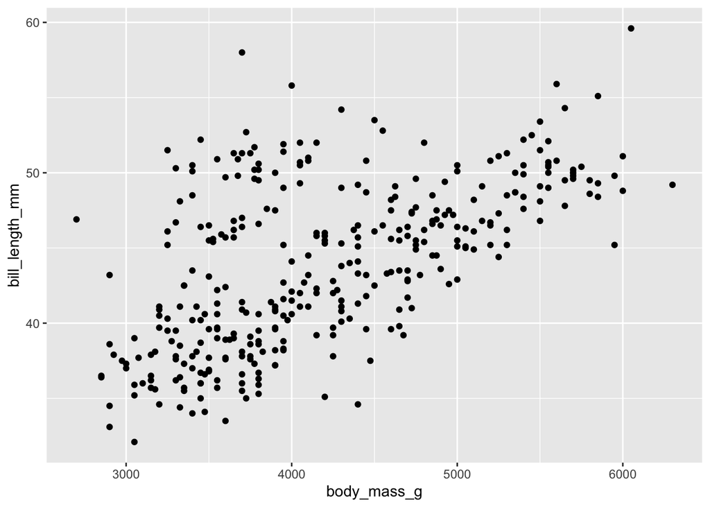

```r
# installation des packages (si besoin)
# install.packages("ggplot2")
# install.packages("dplyr")
# install.packages("palmerpenguins")

# chargement des packages
library(ggplot2)
library(dplyr)
library(palmerpenguins)

# Visualisation de la relation entre masse et longueur du bec
ggplot(data = penguins, mapping = aes(x = body_mass_g, y = bill_length_mm)) +
  geom_point()
```

Notion d’allométrie : un manchot “plus grand” va avoir tendance à peser plus lourd, mais aussi à avoir un plus grand bec, de plus grandes nageoires, etc. Ces variations peuvent s’observer entre espèces ou entre individus d’une même espèce!

2. *Quelles variables (pas nécessairement dans le tableau `penguins`) pourraient avoir une corrélation négative (relation négative) avec `body_mass_g` ? Pourquoi ? Rappelez-vous que nous étudions ici des variables numériques.*

La température moyenne de l’environnement où ils vivent (règle de Bergmann : les individus qui vivent dans des environnements plus froids ont tendance à être plus gros).

Si des données sur le comportement étaient disponibles, le temps passé à jeûner au nid en attendant le retour du partenaire pourrait aussi corréler négativement avec la masse corporelle

3. *Citez les éléments de ce graphique/de ces données qui vous sautent le plus aux yeux ?*
- On note, comme attendu une relation à peu près linéaire et positive
- La masse est très variable entre 3 et 6.5kg, avec toutes les valeurs intermédiaires possibles
- Idem pour la longueur du bec, entre 30 et 60mm
- Pour les manchots les plus légers, il semble y avoir 2 groupes de points : un groupe avec des becs de faible longueur, un groupe avec des becs plus longs. Il nous faudrait plus d’informations pour savoir d’où provient cette variabilité : est-elle liée au sexe ? Aux espèces ?
4. *Créez un nouveau nuage de points en utilisant d’autres variables du jeu de données `penguins`*

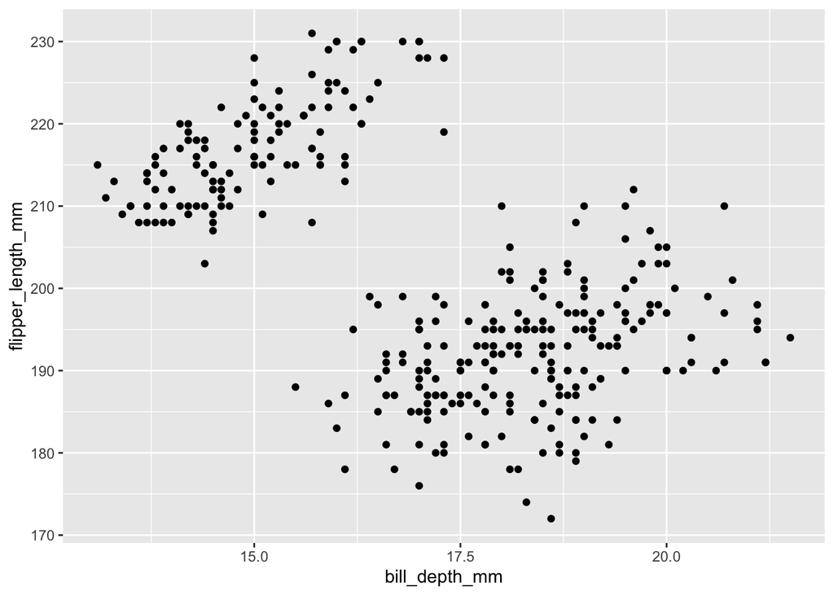

```r
# Pour tester l'hypothèse d'allométrie, on regarde le lien entre la taille de
# deux autres parties du corps : Hauteur du bec et longueur des ailerons
ggplot(data = penguins, mapping = aes(x = bill_depth_mm, y = flipper_length_mm)) +
  geom_point()
```

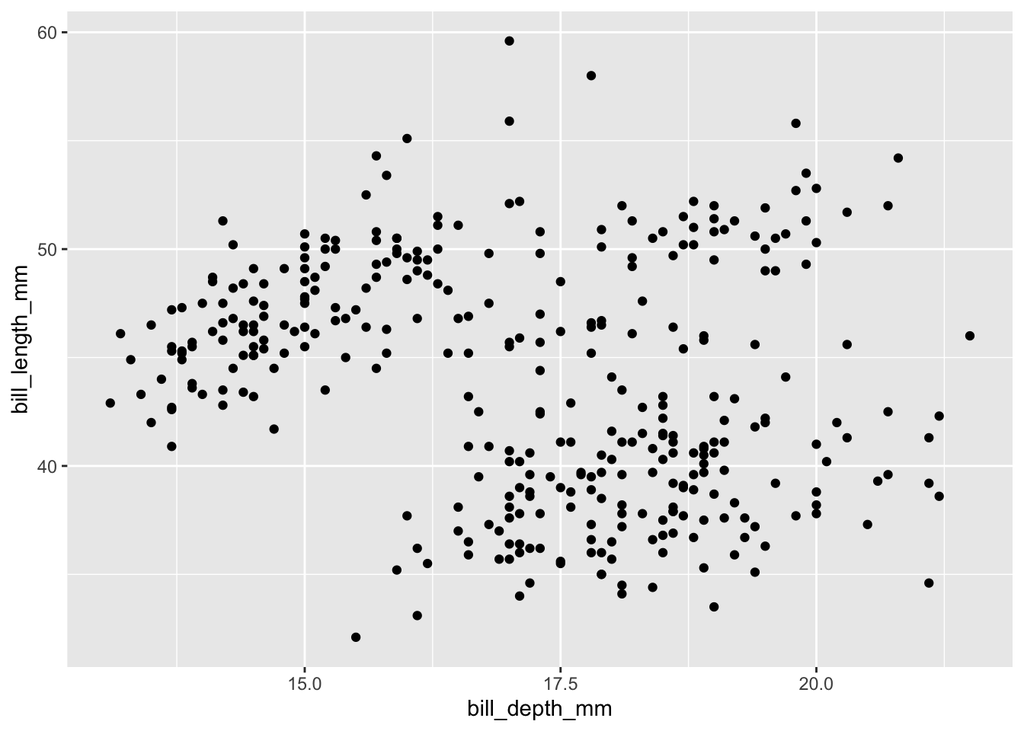

```r
# Dans cette relation on remarque une forte bimodalité : le nuage de points
# se scinde en deux groupes bien distincts, avec une relation positive dans
# chacun de ces sous-groupes. Celà semble confirmer l'hypothèse d'allométrie
# (relation positive générale) mais pointe à des hétérogénéités fortes dans
# le jeu de données, qu'il va falloir comprendre.

# On peut aussi mettre en relation la longueur et l'épaisseur du bec des manchots
ggplot(data = penguins, mapping = aes(x = bill_depth_mm, y = bill_length_mm)) +
  geom_point()
```

```r
# La relation entre ces 2 variables est ici moins évidente. Il semble toutefois
# y avoir plusieurs groupes de points (à gauche, en bas à droite, en haut à droite)
# Là encore, il nous faudrait plus d'informations pour savoir si ces groupes
# correspondent à des différences d'espèces, à des différences entre sexes
# où à toute autre chose.
```

## Exercice 3.4.3

1. *À quoi sert l’argument `stroke` pour les nuages de points et les stripcharts ?*

```r
# installation des packages (si besoins)
# install.packages("ggplot2")
# install.packages("dplyr")
# install.packages("palmerpenguins")

# chargement des packages
library(ggplot2)
library(dplyr)
library(palmerpenguins)
```

On sait que les nuages de points sont appelés par la fonction `geom_point()` ou par `geom_jitter()`. On peut donc commencer par consulter l’aide de `geom_point()` :

```r
?geom_point
```

L’argument `stroke` est mentionné dans le paragraphe `Aesthetics` de l’aide, sans plus d’explication, mais dans la rubrique `Examples`, on trouve ceci :

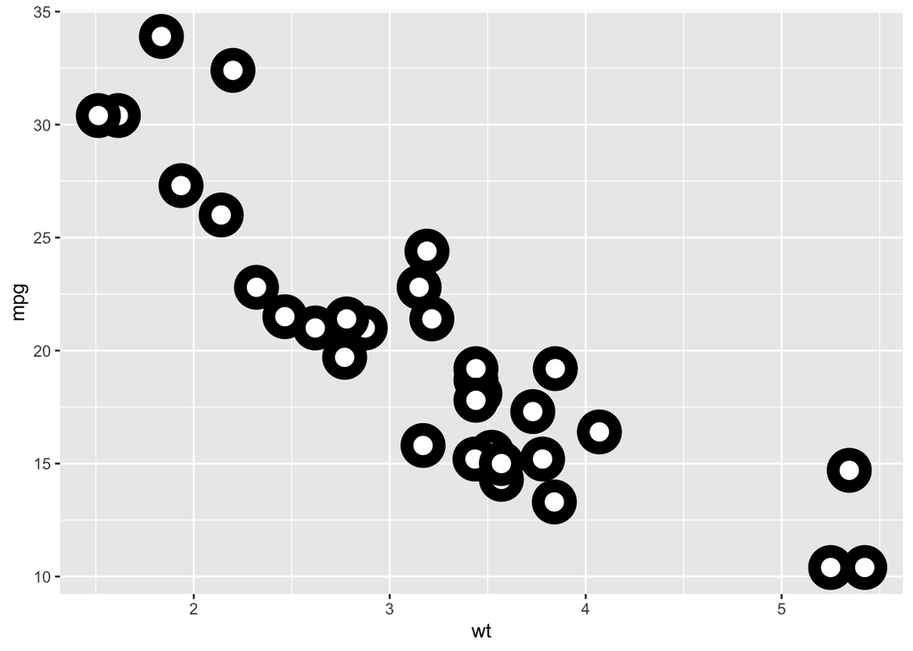

```r
# For shapes that have a border (like 21), you can colour the inside and
# outside separately. Use the stroke aesthetic to modify the width of the
# border
ggplot(mtcars, aes(wt, mpg)) +
  geom_point(shape = 21, colour = "black", fill = "white", size = 5, stroke = 5)
```

2. *Créez de nouveaux graphiques (histogramme et diagramme de densité) avec la variable contenant l’information de la longueur des nageoires des manchots `flipper_length_mm`. Décrivez les graphiques obtenus. Vos observations sont-elles cohérentes avec ce que nous savons maintenant des masses individuelles ?*

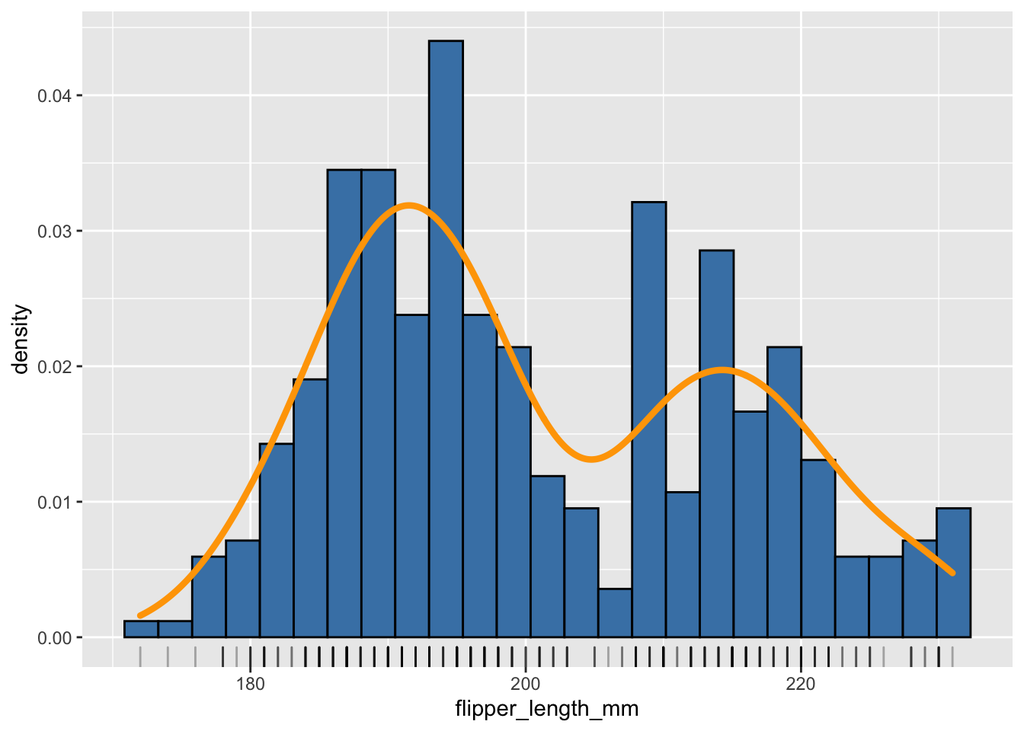

```r
ggplot(penguins, aes(x = flipper_length_mm)) +
  geom_histogram(aes(y = ..density..), bins = 25,
                 fill = "steelblue", color = "black") +
  geom_density(color = "orange", size = 1.5) +
  geom_rug(alpha = 0.3)
```

On retrouve bien une distribution bimodale, avec un pic à 190mm et un autre à 215mm. Les valeurs de rug semblent très concentrées sur quelques valeurs: les mesures sont précises au millimètre près, pas en dessous. Cette distribution correspond à peu près à celle de la masse corporelle

3. *Visualisez ces données avec un nuage de points ou un stripchart. Retrouvez-vous les mêmes informations de distribution ?*

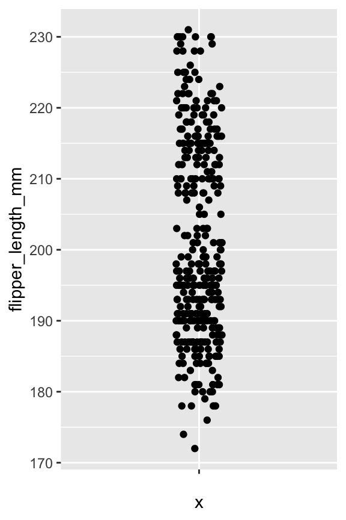

```r
ggplot(penguins, aes(x = "", y = flipper_length_mm)) +
  geom_jitter(width = 0.1, height = 0)
```

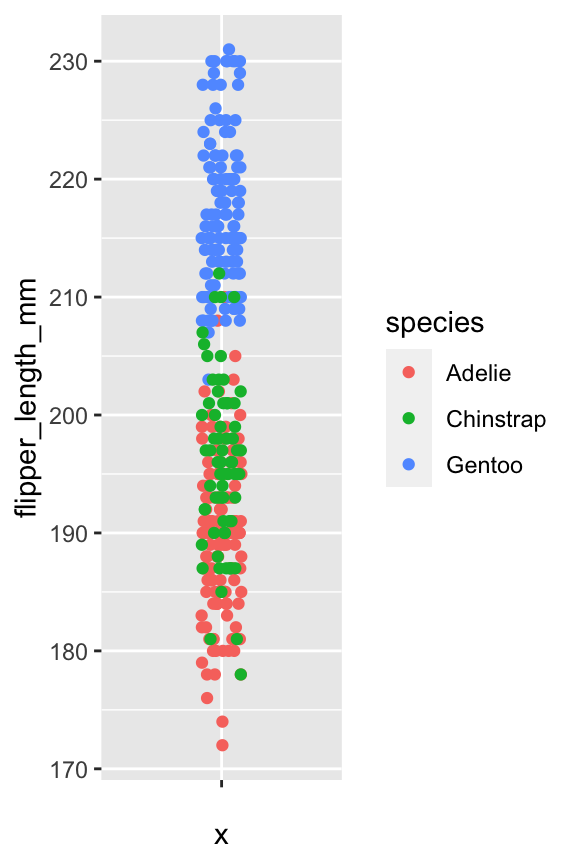

```r
ggplot(penguins, aes(x = "", y = flipper_length_mm, color = species)) +
  geom_jitter(width = 0.1, height = 0)
```

On voit ici que l’espèce Gentoo a des longueurs de nageoires supérieures aux deux autres espèces. Adélie et Chinstrap présentent des valeurs comparables, même si Chinstrap semble présenter des longueurs de nageoires légèrement plus importantes.

## Exercice 3.5.1.3

1. *Quelle est la différence entre un histogramme et un diagramme bâtons ?*

Les deux présentent des “barres de comptage” (un des axes présente un nombre d’observations par catégories ou par classe, en général l’axe des ordonnées). la différence tient à la nature des données utilisées pour les catégories :

- sur un diagramme bâtons on utilise une variable catégorielle (par exemple l’espèce, ou le sexe). En général, il s’agit de facteurs (`factor` dans `RStudio`).
- sur un histogramme on utilise une variable continue, qu’on découpe en classes plus ou moins arbitrairement (par exemple avec les arguments `bins`, `binwidth` ou `breaks` de la fonction `geom_histogram()`)

On peut remarquer cette différence sur les graphiques : - sur un diagramme bâtons ce n’est pas un problème de réordonner les barres, ni d’espacer les barres les unes des autres : les trous entre les barres n’apportent pas d’information - sur un histogramme on ne peut pas réordonner les barres, et elles sont collées les unes aux autres : un “espace” indique une absence d’observations de cette gamme de valeurs

2. *Pourquoi les histogrammes sont-ils inadaptés pour visualiser des données catégorielles ?*

Parce que les histogrammes sont fait pour catégoriser arbitrairement des données continues. On peut faire varier manuellement (ou laisser `RStudio` déterminer automatiquement) la largeur des catégories. Par ailleurs, les barres d’un histogramme sont collées les unes aux autres ce qui donne une impression visuelle de continuité. Enfin, les barres ne peuvent pas être ré-ordonnées, ce qui est souvent nécessaire pour une variable catégorielle.

3. *Pourquoi ne peut-on pas trier un histogramme par ordre croissant ?*

L’ordre des catégories de l’axe des abscisses d’un histogramme est déterminé par les valeurs d’une variable numérique. En ré-ordonnant les classes, on casserait la fonction première de l’histogramme, qui montre comment les observations se répartissent pour des valeurs croissantes de la variable numérique portée par l’axe des abscisses.

4. *Quelle île de l’archipel Palmer a fourni le plus grand nombre de manchots pour cette étude ?*

On souhaite compter le nombre d’individus pour chaque île étudiée. La variable qui sera portée par l’axe des `x` est donc catégorielle (colonne `island` du tableau `penguins`), on fait donc un diagramme bâtons :

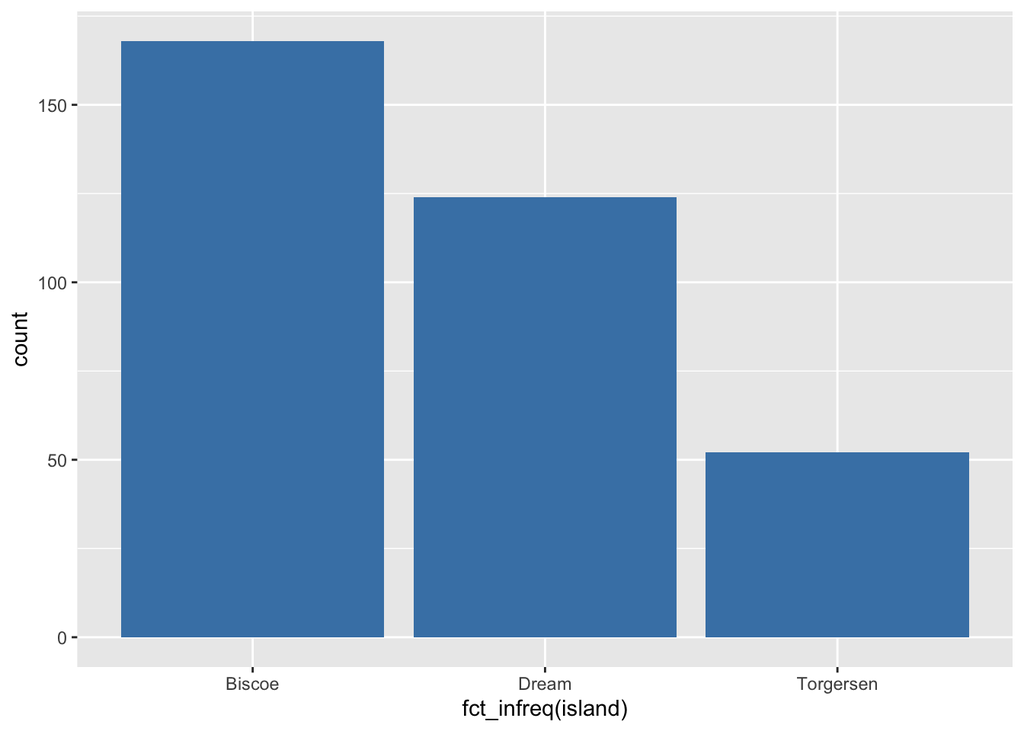

```r
# Installation des packages (si besoin)
# install.packages("ggplot2")
# install.packages("dplyr")
# install.packages("palmerpenguins")

# chargement des packages
library(ggplot2)
library(forcats)
library(palmerpenguins)

ggplot(penguins, aes(x = fct_infreq(island))) +
  geom_bar(fill = "steelblue")
```

Ici, on utilise `geom_bar()` (et non `geom_col()`), car on ne dispose pas d’un tableau qui répertorie déjà dans une colonne le nombre de manchots par îles. Les données ne sont pas déjà pré-comptées.